# Mass 211: Establishing a Baseline for Human Service Demands

## Regression Model Recap

In our previous regression model, we identified income, race and education attainment as the strongest variables in predicting number of 211 calls per capita.

```r
knitr::opts_chunk$set(
  echo = FALSE,
  message = FALSE, warning = FALSE
)
```

```
Call:
lm(formula = p_call ~ MedHouseValue + MedHouseIncome + AtLeastBachelor +
    Black + Hispanic, data = dat)

Residuals:
    Min      1Q  Median      3Q     Max
-20.678  -3.652  -0.840   2.211  67.508

Coefficients:
                  Estimate Std. Error t value Pr(>|t|)
(Intercept)      1.469e+01  1.141e+00  12.870  < 2e-16 ***
MedHouseValue   -4.259e-06  2.747e-06  -1.551 0.121654
MedHouseIncome  -5.951e-05  1.719e-05  -3.461 0.000584 ***
AtLeastBachelor -6.905e+00  3.070e+00  -2.249 0.024960 *
Black            5.295e+01  4.553e+00  11.629  < 2e-16 ***
Hispanic         2.524e+01  3.329e+00   7.583 1.69e-13 ***
---
Signif. codes:  0 ‘***’ 0.001 ‘**’ 0.01 ‘*’ 0.05 ‘.’ 0.1 ‘ ’ 1

Residual standard error: 7.279 on 493 degrees of freedom
  (10 observations deleted due to missingness)
Multiple R-squared:  0.5363,    Adjusted R-squared:  0.5316
F-statistic: 114.1 on 5 and 493 DF,  p-value: < 2.2e-16
```

```r
stargazer(fit, type='html', out='tmp.html')
```

[output not shown]

```r
dat2 <- count.zip %>%
  filter(
    p_call > 0
  ) %>%
  distinct() %>%
  mutate(
    MedHouseValue = MedHouseValue / 1000,
    MedHouseIncome = MedHouseIncome / 1000,
    log_p_call = log(p_call * 10)
  )
```

```r
dat <- zip.geo@data %>%
  filter(
    TotalPop > 100,
  ) %>%
  distinct() %>%
  mutate(
    # fill NA value with median
    MedHouseValue = if_else(is.na(MedHouseValue), median(MedHouseValue, na.rm=T), MedHouseValue),
    MedHouseValue = MedHouseValue / 1000,
    MedHouseIncome = if_else(is.na(MedHouseIncome), median(MedHouseIncome, na.rm=T), MedHouseIncome),
    MedHouseIncome = MedHouseIncome / 1000,
    log_p_call = log(p_call * 10)
  )
fit <- lm(p_call ~ MedHouseValue + MedHouseIncome + AtLeastBachelor + Black + Hispanic, data=dat)
summary(fit)
```

```
Call:
lm(formula = p_call ~ MedHouseValue + MedHouseIncome + AtLeastBachelor +
    Black + Hispanic, data = dat)

Residuals:
    Min      1Q  Median      3Q     Max
-20.807  -3.403  -0.786   2.213  67.728

Coefficients:
                 Estimate Std. Error t value Pr(>|t|)
(Intercept)     13.890633   1.122544  12.374  < 2e-16 ***
MedHouseValue   -0.003947   0.002632  -1.500  0.13437
MedHouseIncome  -0.051640   0.016500  -3.130  0.00186 **
AtLeastBachelor -7.182128   2.873777  -2.499  0.01278 *
Black           54.313924   4.355398  12.470  < 2e-16 ***
Hispanic        25.522658   3.184957   8.014 8.31e-15 ***
---
Signif. codes:  0 ‘***’ 0.001 ‘**’ 0.01 ‘*’ 0.05 ‘.’ 0.1 ‘ ’ 1

Residual standard error: 6.922 on 487 degrees of freedom
Multiple R-squared:  0.5604,    Adjusted R-squared:  0.5559
F-statistic: 124.1 on 5 and 487 DF,  p-value: < 2.2e-16
```

```r
fit <- lm(p_call ~ HI_PrivateInsured + MedHouseIncome + AtLeastBachelor + Black + Hispanic, data=dat)
summary(fit)
```

```
Call:
lm(formula = p_call ~ HI_PrivateInsured + MedHouseIncome + AtLeastBachelor +
    Black + Hispanic, data = dat)

Residuals:
    Min      1Q  Median      3Q     Max
-17.135  -3.204  -0.297   2.206  60.838

Coefficients:
                    Estimate Std. Error t value Pr(>|t|)
(Intercept)        36.642620   3.273399  11.194  < 2e-16 ***
HI_PrivateInsured -36.290820   4.949647  -7.332 9.52e-13 ***
MedHouseIncome      0.003739   0.017409   0.215   0.8300
AtLeastBachelor    -4.348840   2.351416  -1.849   0.0650 .
Black              46.239809   4.246593  10.889  < 2e-16 ***
Hispanic            7.200319   3.901634   1.845   0.0656 .
---
Signif. codes:  0 ‘***’ 0.001 ‘**’ 0.01 ‘*’ 0.05 ‘.’ 0.1 ‘ ’ 1

Residual standard error: 6.584 on 487 degrees of freedom
Multiple R-squared:  0.6022,    Adjusted R-squared:  0.5982
F-statistic: 147.5 on 5 and 487 DF,  p-value: < 2.2e-16
```

```r
dat <- dat %>%
  mutate(
  )
fit <- lm(p_call ~ HI_PrivateInsured + Black + MedHouseValue + ChildInNeed, data=dat)
summary(fit)
```

```
Call:
lm(formula = p_call ~ HI_PrivateInsured + Black + MedHouseValue +
    ChildInNeed, data = dat)

Residuals:
    Min      1Q  Median      3Q     Max
-14.865  -3.377  -0.200   2.163  58.981

Coefficients:
                    Estimate Std. Error t value Pr(>|t|)
(Intercept)        29.077775   3.743505   7.768 4.77e-14 ***
HI_PrivateInsured -28.018886   4.250933  -6.591 1.14e-10 ***
Black              45.558167   4.184433  10.888  < 2e-16 ***
MedHouseValue      -0.005353   0.001751  -3.057 0.002358 **
ChildInNeed        11.443066   3.266932   3.503 0.000503 ***
---
Signif. codes:  0 ‘***’ 0.001 ‘**’ 0.01 ‘*’ 0.05 ‘.’ 0.1 ‘ ’ 1

Residual standard error: 6.362 on 487 degrees of freedom
  (1 observation deleted due to missingness)
Multiple R-squared:  0.6228,    Adjusted R-squared:  0.6197
F-statistic:   201 on 4 and 487 DF,  p-value: < 2.2e-16
```

```r
fit <- lm(p_call ~ HI_PrivateInsured + Black + p.urbanized_pop, data=dat)
summary(fit)
```

```
Call:
lm(formula = p_call ~ HI_PrivateInsured + Black + p.urbanized_pop,
    data = dat)

Residuals:
    Min      1Q  Median      3Q     Max
-16.353  -3.168  -0.434   2.350  59.234

Coefficients:
                    Estimate Std. Error t value Pr(>|t|)
(Intercept)        39.931836   2.085044  19.152  < 2e-16 ***
HI_PrivateInsured -45.000751   2.519354 -17.862  < 2e-16 ***
Black              41.296107   4.269490   9.672  < 2e-16 ***
p.urbanized_pop     0.035989   0.007881   4.566 6.28e-06 ***
---
Signif. codes:  0 ‘***’ 0.001 ‘**’ 0.01 ‘*’ 0.05 ‘.’ 0.1 ‘ ’ 1

Residual standard error: 6.474 on 489 degrees of freedom
Multiple R-squared:  0.6139,    Adjusted R-squared:  0.6115
F-statistic: 259.1 on 3 and 489 DF,  p-value: < 2.2e-16
```

```r
summary(m2 <- MASS::glm.nb(
  n_call ~ White +
    MedHouseValue +
    MedHouseIncome +
    OwnerOccupied +
    HH_LiveAlone +
    HH_SingleHead +
    # HI_PrivateInsured +
    AtLeastBachelor +
    PopDen +
    offset(log(TotalPop)),
  data = dat))
```

```
Call:
MASS::glm.nb(formula = n_call ~ White + MedHouseValue + MedHouseIncome +
    OwnerOccupied + HH_LiveAlone + HH_SingleHead + AtLeastBachelor +
    PopDen + offset(log(TotalPop)), data = dat, init.theta = 3.892583842,
    link = log)

Deviance Residuals:
    Min       1Q   Median       3Q      Max
-3.5325  -0.8482  -0.1625   0.4849   4.8355

Coefficients:
                  Estimate Std. Error z value Pr(>|z|)
(Intercept)     -4.744e+00  3.787e-01 -12.527  < 2e-16 ***
White           -1.002e+00  2.523e-01  -3.970 7.18e-05 ***
MedHouseValue   -1.716e-03  2.695e-04  -6.367 1.92e-10 ***
MedHouseIncome   6.707e-03  2.151e-03   3.118  0.00182 **
OwnerOccupied   -2.725e-01  2.328e-01  -1.170  0.24189
HH_LiveAlone     3.946e+00  4.242e-01   9.304  < 2e-16 ***
HH_SingleHead    2.694e+00  6.467e-01   4.166 3.10e-05 ***
AtLeastBachelor -1.250e+00  2.731e-01  -4.576 4.74e-06 ***
PopDen          -4.502e-05  4.714e-05  -0.955  0.33953
---
Signif. codes:  0 ‘***’ 0.001 ‘**’ 0.01 ‘*’ 0.05 ‘.’ 0.1 ‘ ’ 1

(Dispersion parameter for Negative Binomial(3.8926) family taken to be 1)

    Null deviance: 1475.73  on 492  degrees of freedom
Residual deviance:  562.62  on 484  degrees of freedom
AIC: 4748.8

Number of Fisher Scoring iterations: 1

              Theta:  3.893
          Std. Err.:  0.290

 2 x log-likelihood:  -4728.826
```

```r
library(stargazer)
stargazer(fit, type='html', out='tmp.html')
```

[output not shown]

The conclusion was that Black population with lower income and less education are more likely to make 211 calls. This is true at both the zip code and the city/town level.

## Urban vs Rural

To answer the question of whether there are differen behaviors between residents in rural and urban areas, I used the [Urban Area to ZIP Code Tabulation Area Relationship Data](https://www.census.gov/geo/maps-data/data/ua_rel_download.html) to calculate percentage of urban population in each zip code.

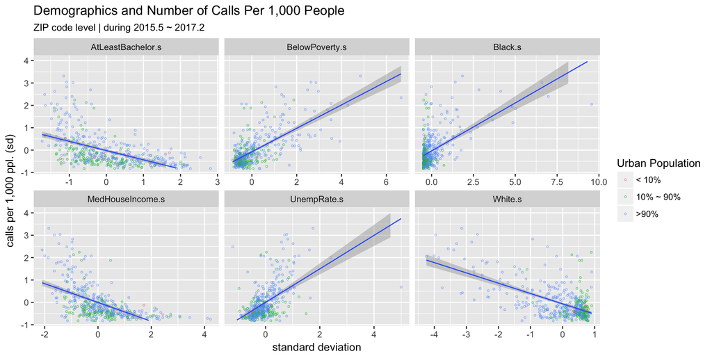

Above graph shows how each demographic characteristic interacts with number of 211 calls, with the color of the dots indicating whether a zip code is considered urban (with more than 90% of the population reside in an urban area), rural (less than 10% people reside in an urban area), or mixed.

If we build a single variable regression model with only urban population percentage, we get a low p-value, but also a very low $R^2$, indicating that rural residents do make less 211 calls, but linear models in this case could not explain most obvervations, since almost all residents (more than 92%) in Massachussets live in urba areas (as defined by the Census Bureau).

```
Call:
lm(formula = p.call ~ p.urbanpop, data = count.zip)

Residuals:
   Min     1Q Median     3Q    Max
-4.631 -2.662 -1.389  0.905 34.728

Coefficients:
            Estimate Std. Error t value Pr(>|t|)
(Intercept) 1.535005   0.836169   1.836  0.06704 .
p.urbanpop  0.030964   0.009491   3.263  0.00119 **
---
Signif. codes:  0 ‘***’ 0.001 ‘**’ 0.01 ‘*’ 0.05 ‘.’ 0.1 ‘ ’ 1

Residual standard error: 4.858 on 462 degrees of freedom
  (68 observations deleted due to missingness)
Multiple R-squared:  0.02252,   Adjusted R-squared:  0.02041
F-statistic: 10.64 on 1 and 462 DF,  p-value: 0.001186
```

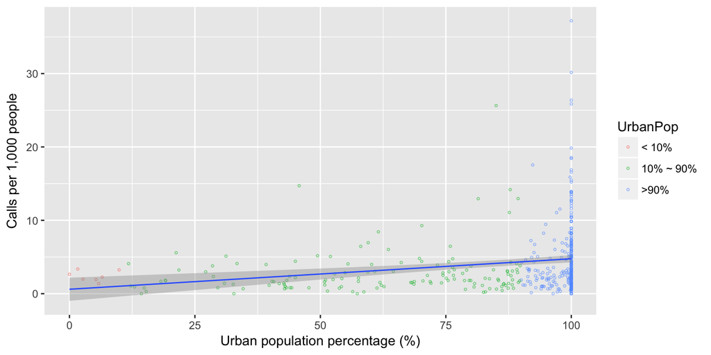

## Data Representation without EEC[^1] Calls

When removed calls related to EEC programs (Taxonomy Code: NL-3000.1500), the results are not that much different.

```
Call:
lm(formula = p.call.s ~ MedHouseIncome.s + AtLeastBachelor.s +
    White.s, data = dat)

Residuals:
    Min      1Q  Median      3Q     Max
-2.2821 -0.4122 -0.1319  0.1841  6.6472

Coefficients:
                   Estimate Std. Error t value Pr(>|t|)
(Intercept)        0.008312   0.036292   0.229   0.8189
MedHouseIncome.s  -0.134143   0.052765  -2.542   0.0113 *
AtLeastBachelor.s -0.271186   0.053057  -5.111 4.53e-07 ***
White.s           -0.381885   0.038134 -10.014  < 2e-16 ***
---
Signif. codes:  0 ‘***’ 0.001 ‘**’ 0.01 ‘*’ 0.05 ‘.’ 0.1 ‘ ’ 1

Residual standard error: 0.8243 on 512 degrees of freedom
  (16 observations deleted due to missingness)
Multiple R-squared:  0.3314,    Adjusted R-squared:  0.3275
F-statistic: 84.59 on 3 and 512 DF,  p-value: < 2.2e-16
```

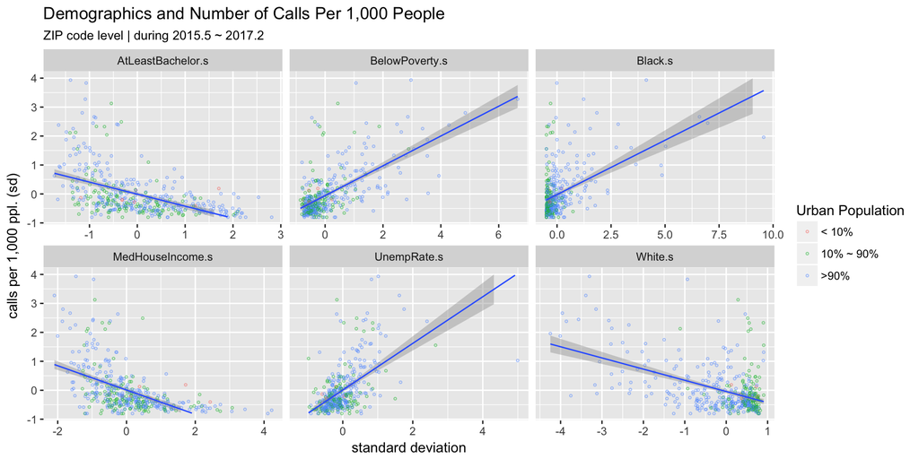

The correlation signal in median house income becomes slightly weaker, suggesting that people in need of Child Care Expense support might live in an even poorer neighborhood than an average 211 user.

## Rediduals

Perhaps what is more interesting is the difference between an area’s predicted number of calls and the actuall call volume, which is reflected by the rediduals in the linear regression model.

[output not shown]

The next step would be to plot these residuals on a map, so to get an intuitive picture of where the demands are the most different than the predictions.

[^1]: Early Education and Care Programs